# Avani -Technical Round for bank data

## Part 1: Project Backgroung

Nowadays, banking industries are spending a major part of its budget on marketing. To get best result banks need to optimise their banking strategies and for that understanding what their customer wants is necessary. This will also help them to make better marketing plans and design products that people actually need. This will not only improves customer satistfaction but also makes their marketing efforts more effective overall.

#### Main objective: Strategies to enhance cx engagement in bank's telemarketing campaign

This project will help bank to get know its customers better and create a profile for futire marketing. By analyzing customer features, such as demographics and transaction history, the bank will be able to predict customer saving behaviors and identity which type of customers is more likely to make term deposits. This will help to focus on those customers who has higher changes of getting converted. Moreover this with increase customer satistfaction by reducing undesirable advertisments for certain customers.

#### importing the libraries

```python
import pandas as pd
import numpy as np
import matplotlib.pyplot as plt
import seaborn as sns
```

```python
path = "C:\\Users\\avnip\\OneDrive\\Desktop\\Data Analysis material\\Busy QA Coop\\interviews\\bankdata.csv"
df = pd.read_csv(path, sep = ";")
df
```

|  | age | job | marital | education | default | housing | loan | contact | month | day_of_week | ... | campaign | pdays | previous | poutcome | emp.var.rate | cons.price.idx | cons.conf.idx | euribor3m | nr.employed | y |
| --- | --- | --- | --- | --- | --- | --- | --- | --- | --- | --- | --- | --- | --- | --- | --- | --- | --- | --- | --- | --- | --- |
| 0 | 56 | housemaid | married | basic.4y | no | no | no | telephone | may | mon | ... | 1 | 999 | 0 | nonexistent | 1.1 | 93.994 | -36.4 | 4.857 | 5191.0 | no |
| 1 | 57 | services | married | high.school | unknown | no | no | telephone | may | mon | ... | 1 | 999 | 0 | nonexistent | 1.1 | 93.994 | -36.4 | 4.857 | 5191.0 | no |
| 2 | 37 | services | married | high.school | no | yes | no | telephone | may | mon | ... | 1 | 999 | 0 | nonexistent | 1.1 | 93.994 | -36.4 | 4.857 | 5191.0 | no |
| 3 | 40 | admin. | married | basic.6y | no | no | no | telephone | may | mon | ... | 1 | 999 | 0 | nonexistent | 1.1 | 93.994 | -36.4 | 4.857 | 5191.0 | no |
| 4 | 56 | services | married | high.school | no | no | yes | telephone | may | mon | ... | 1 | 999 | 0 | nonexistent | 1.1 | 93.994 | -36.4 | 4.857 | 5191.0 | no |
| ... | ... | ... | ... | ... | ... | ... | ... | ... | ... | ... | ... | ... | ... | ... | ... | ... | ... | ... | ... | ... | ... |
| 41184 | 73 | retired | married | professional.course | no | yes | no | cellular | nov | fri | ... | 1 | 999 | 0 | nonexistent | -1.1 | 94.767 | -50.8 | 1.028 | 4963.6 | yes |
| 41185 | 46 | blue-collar | married | professional.course | no | no | no | cellular | nov | fri | ... | 1 | 999 | 0 | nonexistent | -1.1 | 94.767 | -50.8 | 1.028 | 4963.6 | no |
| 41186 | 56 | retired | married | university.degree | no | yes | no | cellular | nov | fri | ... | 2 | 999 | 0 | nonexistent | -1.1 | 94.767 | -50.8 | 1.028 | 4963.6 | no |
| 41187 | 44 | technician | married | professional.course | no | no | no | cellular | nov | fri | ... | 1 | 999 | 0 | nonexistent | -1.1 | 94.767 | -50.8 | 1.028 | 4963.6 | yes |
| 41188 | 74 | retired | married | professional.course | no | yes | no | cellular | nov | fri | ... | 3 | 999 | 1 | failure | -1.1 | 94.767 | -50.8 | 1.028 | 4963.6 | no |

41189 rows × 21 columns

This dataset has 41189 observation. Each representing cx that the bank reached via phone calls.

```python
#Analyzing Dataset Dimensions: Rows and Columns
df.shape
```

```
(41189, 21)
```

```python
# making a copy of the file
data_copy = df
```

```python
#understang columns names and datatype
data_copy.info()
```

```
<class 'pandas.core.frame.DataFrame'>
RangeIndex: 41189 entries, 0 to 41188
Data columns (total 21 columns):
 #   Column          Non-Null Count  Dtype
---  ------          --------------  -----
 0   age             41189 non-null  int64
 1   job             41189 non-null  object
 2   marital         41189 non-null  object
 3   education       41189 non-null  object
 4   default         41189 non-null  object
 5   housing         41189 non-null  object
 6   loan            41189 non-null  object
 7   contact         41189 non-null  object
 8   month           41189 non-null  object
 9   day_of_week     41189 non-null  object
 10  duration        41189 non-null  int64
 11  campaign        41189 non-null  int64
 12  pdays           41189 non-null  int64
 13  previous        41189 non-null  int64
 14  poutcome        41189 non-null  object
 15  emp.var.rate    41189 non-null  float64
 16  cons.price.idx  41189 non-null  float64
 17  cons.conf.idx   41189 non-null  float64
 18  euribor3m       41189 non-null  float64
 19  nr.employed     41189 non-null  float64
 20  y               41189 non-null  object
dtypes: float64(5), int64(5), object(11)
memory usage: 6.6+ MB
```

#### Cleaning Dataset

```python
#Checking for missing/null values
data_copy.isna().sum()
```

```
age               0
job               0
marital           0
education         0
default           0
housing           0
loan              0
contact           0
month             0
day_of_week       0
duration          0
campaign          0
pdays             0
previous          0
poutcome          0
emp.var.rate      0
cons.price.idx    0
cons.conf.idx     0
euribor3m         0
nr.employed       0
y                 0
dtype: int64
```

There is on missing values in the dataset. Nevertheless, there are values like "unknown", "others" can be equivalent to missing values depending on clients requirment. For now these ambiguous values are considered to be relevant to the analysis.

```python
data_copy1 = data_copy
```

```python
#Checking duplicates
data_copy1.duplicated().sum()
```

[output not shown]

```python
# droping duplicates
data_copy1 = data_copy1.drop_duplicates()
```

```python
data_copy1.describe()
```

|  | age | duration | campaign | pdays | previous | emp.var.rate | cons.price.idx | cons.conf.idx | euribor3m | nr.employed |
| --- | --- | --- | --- | --- | --- | --- | --- | --- | --- | --- |
| count | 41176.00000 | 41176.000000 | 41176.000000 | 41176.000000 | 41176.000000 | 41176.000000 | 41176.000000 | 41176.000000 | 41176.000000 | 41176.000000 |
| mean | 40.02380 | 258.315815 | 2.567879 | 962.464810 | 0.173013 | 0.081922 | 93.575720 | -40.502863 | 3.621293 | 5167.034870 |
| std | 10.42068 | 259.305321 | 2.770318 | 186.937102 | 0.494964 | 1.570883 | 0.578839 | 4.627860 | 1.734437 | 72.251364 |
| min | 17.00000 | 0.000000 | 1.000000 | 0.000000 | 0.000000 | -3.400000 | 92.201000 | -50.800000 | 0.634000 | 4963.600000 |
| 25% | 32.00000 | 102.000000 | 1.000000 | 999.000000 | 0.000000 | -1.800000 | 93.075000 | -42.700000 | 1.344000 | 5099.100000 |
| 50% | 38.00000 | 180.000000 | 2.000000 | 999.000000 | 0.000000 | 1.100000 | 93.749000 | -41.800000 | 4.857000 | 5191.000000 |
| 75% | 47.00000 | 319.000000 | 3.000000 | 999.000000 | 0.000000 | 1.400000 | 93.994000 | -36.400000 | 4.961000 | 5228.100000 |
| max | 98.00000 | 4918.000000 | 56.000000 | 999.000000 | 7.000000 | 1.400000 | 94.767000 | -26.900000 | 5.045000 | 5228.100000 |

```python
#getting the list/ summary of categorical Columns
categorical = data_copy1.dtypes[data_copy.dtypes == 'object'].index
print(categorical)

data_copy[categorical].describe()
```

```
Index(['job', 'marital', 'education', 'default', 'housing', 'loan', 'contact',
       'month', 'day_of_week', 'poutcome', 'y'],
      dtype='object')
```

|  | job | marital | education | default | housing | loan | contact | month | day_of_week | poutcome | y |
| --- | --- | --- | --- | --- | --- | --- | --- | --- | --- | --- | --- |
| count | 41189 | 41189 | 41189 | 41189 | 41189 | 41189 | 41189 | 41189 | 41189 | 41189 | 41189 |
| unique | 12 | 4 | 8 | 3 | 3 | 3 | 2 | 10 | 5 | 3 | 2 |
| top | admin. | married | university.degree | no | yes | no | cellular | may | thu | nonexistent | no |
| freq | 10422 | 24929 | 12168 | 32589 | 21577 | 33951 | 26144 | 13770 | 8623 | 35564 | 36549 |

```python
#Checking unique values in each column
for column in data_copy1.columns:
    unique_values = data_copy1[column].unique()
    print(f'{column}:')
    print(f'    {", ".join(map(str, unique_values))}')
    print('-' * 40)
```

```
age:
    56, 57, 37, 40, 45, 59, 41, 24, 25, 29, 35, 54, 46, 50, 39, 30, 55, 49, 34, 52, 58, 32, 38, 44, 42, 60, 53, 47, 51, 48, 33, 31, 43, 36, 28, 27, 26, 22, 23, 20, 21, 61, 19, 18, 70, 66, 76, 67, 73, 88, 95, 77, 68, 75, 63, 80, 62, 65, 72, 82, 64, 71, 69, 78, 85, 79, 83, 81, 74, 17, 87, 91, 86, 98, …
----------------------------------------
job:
    housemaid, services, admin., blue-collar, technician, retired, management, unemployed, self-employed, unknown, entrepreneur, student
----------------------------------------
marital:
    married, single, divorced, unknown
----------------------------------------
education:
    basic.4y, high.school, basic.6y, basic.9y, professional.course, unknown, university.degree, illiterate
----------------------------------------
default:
    no, unknown, yes
----------------------------------------
housing:
    no, yes, unknown
----------------------------------------
loan:
    no, yes, unknown
----------------------------------------
contact:
    telephone, cellular
----------------------------------------
month:
    may, jun, jul, aug, oct, nov, dec, mar, apr, sep
----------------------------------------
day_of_week:
    mon, tue, wed, thu, fri
----------------------------------------
duration:
    261, 149, 226, 151, 307, 198, 139, 217, 380, 50, 55, 222, 137, 293, 146, 174, 312, 440, 353, 195, 38, 262, 342, 181, 172, 99, 93, 233, 255, 362, 348, 386, 73, 230, 208, 336, 365, 1666, 577, 366, 314, 160, 212, 188, 22, 616, 178, 355, 225, 266, 253, 179, 269, 135, 161, 787, 145, 449, 812, 164, 35…
----------------------------------------
campaign:
    1, 2, 3, 4, 5, 6, 7, 8, 9, 10, 11, 12, 13, 19, 18, 23, 14, 22, 25, 16, 17, 15, 20, 56, 39, 35, 42, 28, 26, 27, 32, 21, 24, 29, 31, 30, 41, 37, 40, 33, 34, 43
----------------------------------------
pdays:
    999, 6, 4, 3, 5, 1, 0, 10, 7, 8, 9, 11, 2, 12, 13, 14, 15, 16, 21, 17, 18, 22, 25, 26, 19, 27, 20
----------------------------------------
previous:
```

[output cut: 8 more lines]

```
cons.price.idx:
    93.994, 94.465, 93.918, 93.444, 93.798, 93.2, 92.756, 92.843, 93.075, 92.893, 92.963, 92.469, 92.201, 92.379, 92.431, 92.649, 92.713, 93.369, 93.749, 93.876, 94.055, 94.215, 94.027, 94.199, 94.601, 94.767
----------------------------------------
cons.conf.idx:
    -36.4, -41.8, -42.7, -36.1, -40.4, -42.0, -45.9, -50.0, -47.1, -46.2, -40.8, -33.6, -31.4, -29.8, -26.9, -30.1, -33.0, -34.8, -34.6, -40.0, -39.8, -40.3, -38.3, -37.5, -49.5, -50.8
----------------------------------------
euribor3m:
    4.857, 4.856, 4.855, 4.859, 4.86, 4.858, 4.864, 4.865, 4.866, 4.967, 4.961, 4.959, 4.958, 4.96, 4.962, 4.955, 4.947, 4.956, 4.966, 4.963, 4.957, 4.968, 4.97, 4.965, 4.964, 5.045, 5.0, 4.936, 4.921, 4.918, 4.912, 4.827, 4.794, 4.76, 4.733, 4.7, 4.663, 4.592, 4.474, 4.406, 4.343, 4.286, 4.245, 4.2…
----------------------------------------
nr.employed:
    5191.0, 5228.1, 5195.8, 5176.3, 5099.1, 5076.2, 5017.5, 5023.5, 5008.7, 4991.6, 4963.6
----------------------------------------
y:
    no, yes
----------------------------------------
```

#### Uni-Varient Analysis

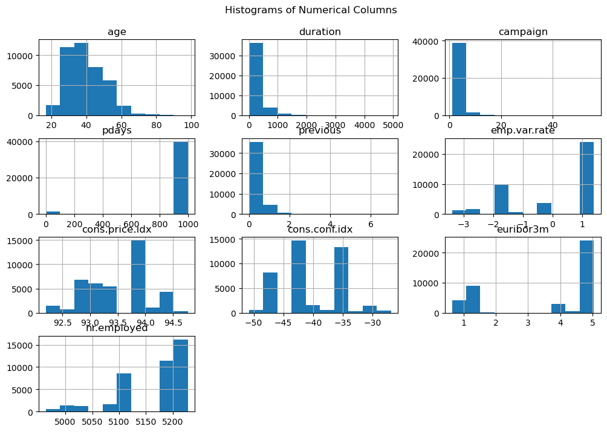

```python
#understanding the skewness of the numerical columns

# Plot histograms for numerical columns
data_copy1.hist(bins=10, figsize=(12, 8))
plt.suptitle('Histograms of Numerical Columns', y=0.95)
plt.show()
```

#### outliers analysis

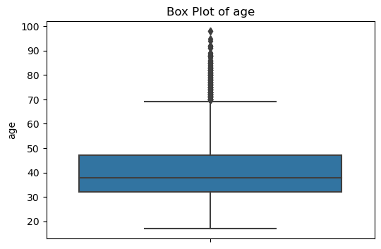

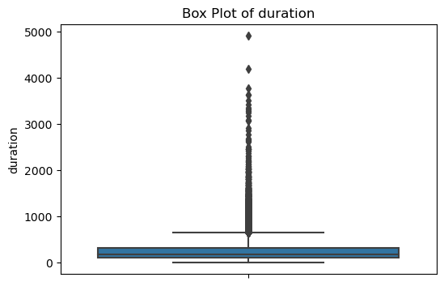

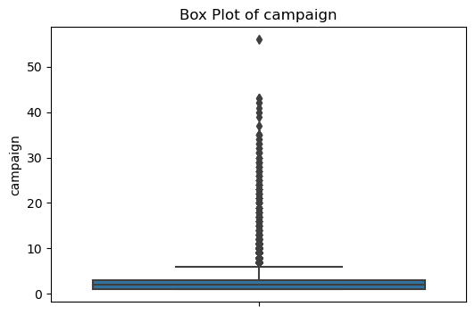

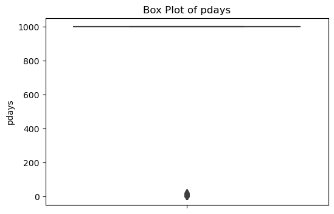

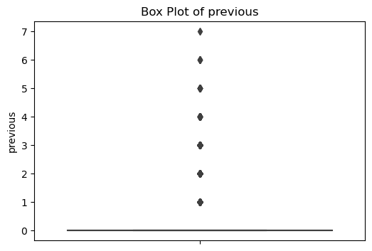

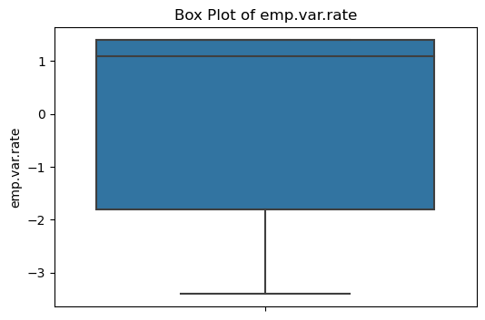

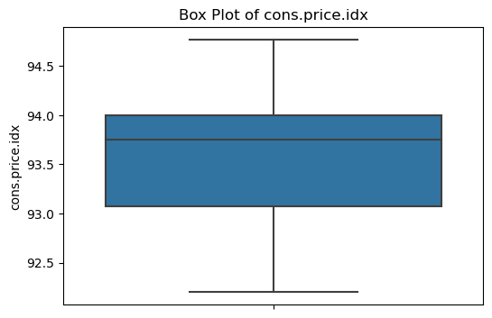

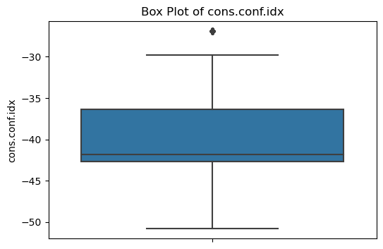

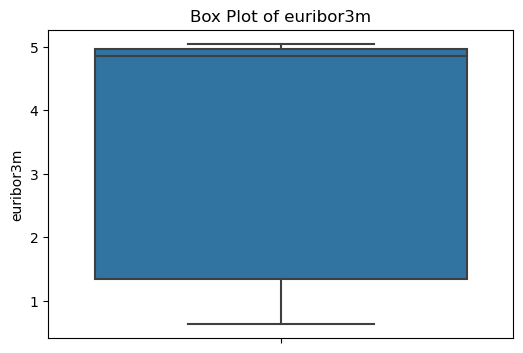

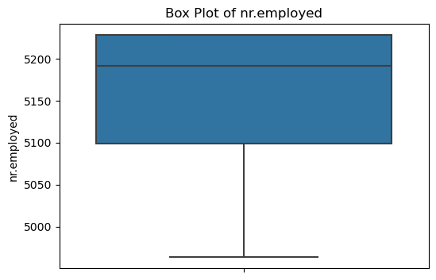

```python
# Create individual box plots for each numerical column
for column in data_copy.select_dtypes(include='number').columns:
    plt.figure(figsize=(6, 4))
    sns.boxplot(y=data_copy[column])
    plt.title(f'Box Plot of {column}')
    plt.show()
```

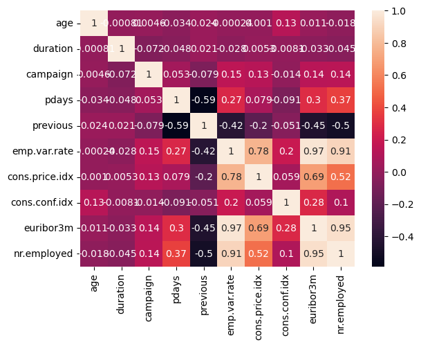

```python
# Correlation matrix
correlation_matrix = data_copy1.corr()

sns.heatmap(correlation_matrix, annot=True)
plt.show()
```

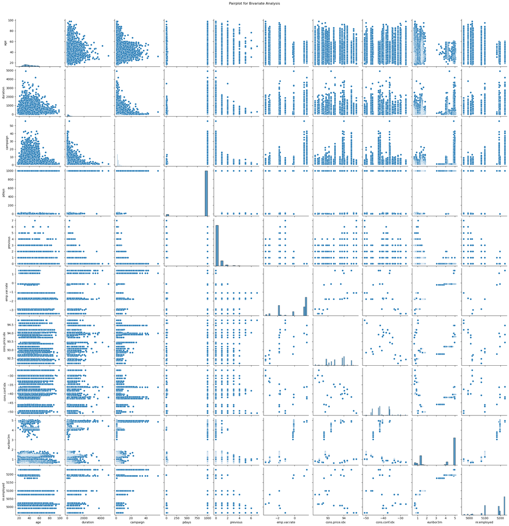

```python
# Pairplot for bivariate analysis
sns.pairplot(data_copy1)
plt.suptitle('Pairplot for Bivariate Analysis', y=1.02)
plt.show()
```

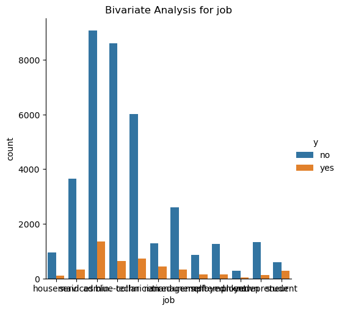

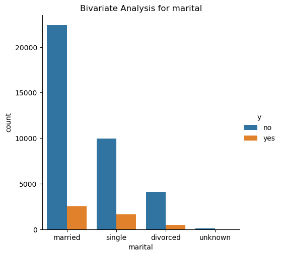

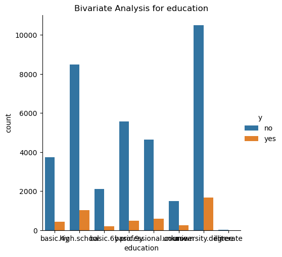

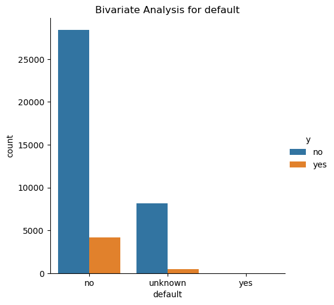

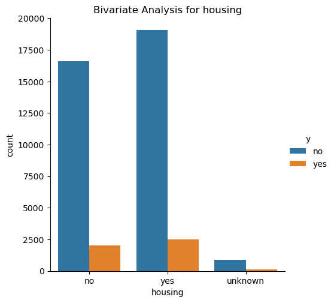

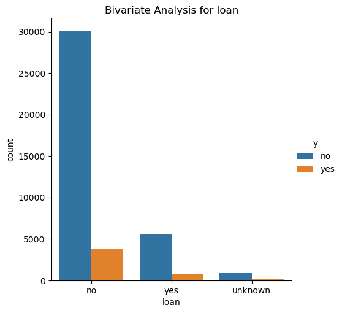

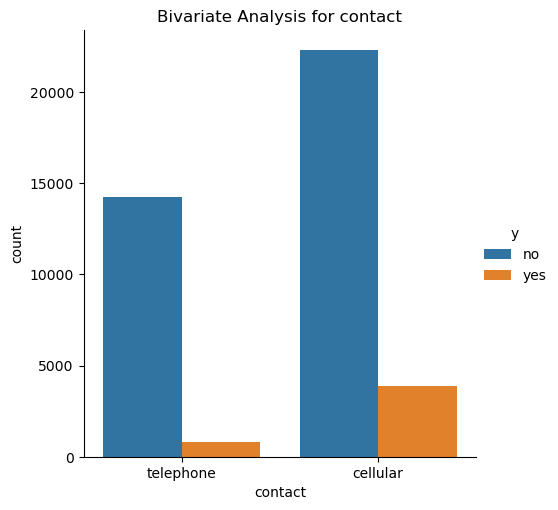

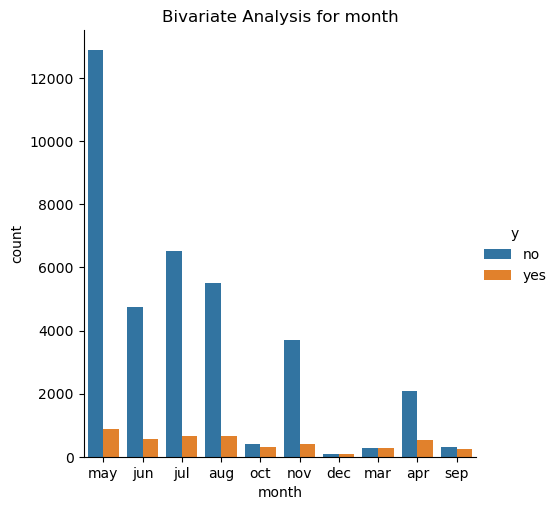

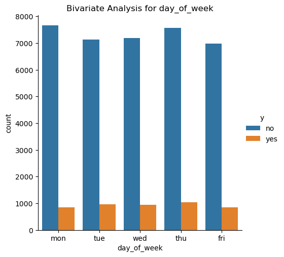

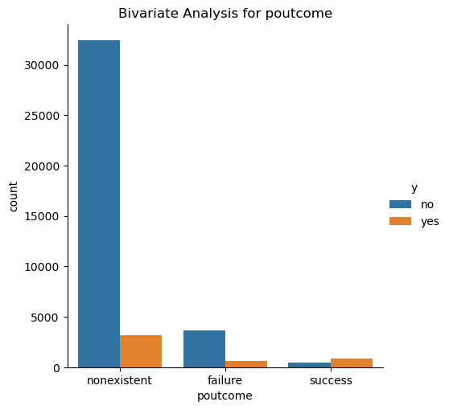

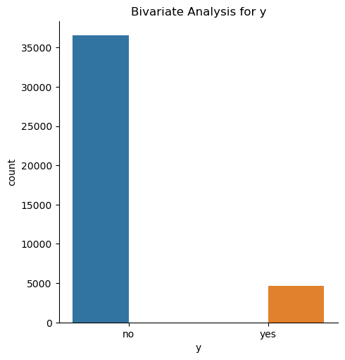

```python
for column in data_copy1.select_dtypes(include='object').columns:
    plt.figure(figsize=(20, 10))
    sns.catplot(x=column, hue='y', kind='count', data = data_copy1)
    plt.title(f'Bivariate Analysis for {column}')
    plt.show()
```

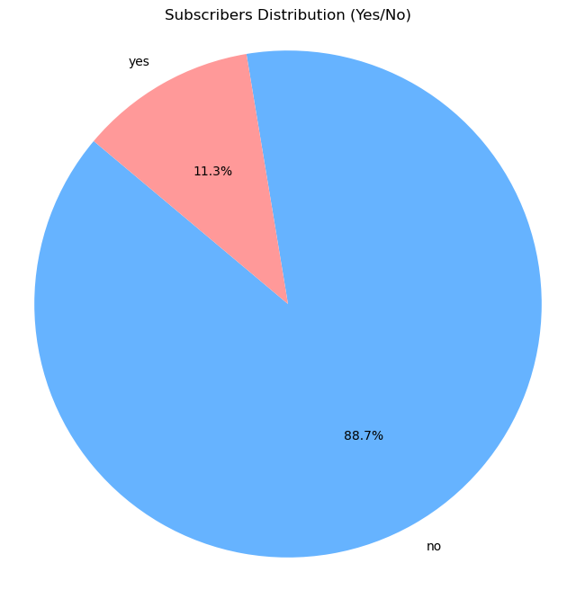

```python
# % subcribers out of total
# Group by the 'y' column and calculate the count
y_group_analysis = data_copy1['y'].value_counts()

# Prepare data for the pie chart
labels = y_group_analysis.index
sizes = y_group_analysis.values

# Plotting
plt.figure(figsize=(8, 8))
plt.pie(sizes, labels=labels, autopct='%1.1f%%', startangle=140, colors=['#66b3ff','#ff9999'])
plt.title('Subscribers Distribution (Yes/No)')
plt.axis('equal')  # Equal aspect ratio ensures that pie is drawn as a circle.

plt.show()
```

This graph illustrated that only 11.3% of the customers subscribed the term deposit offered by the marketing campaign.

#### Data Modeling for visualisation

```python
#binning age group
data_copy1['age_bin'] = pd.cut(data_copy1['age'],
                              bins=[0, 30, 39, 49, 59, float('inf')],
                              labels=['<30', '30-39', '40-49', '50-59', '60+'])

# Print the first few rows to verify the changes
print(data_copy1[['age', 'age_bin']])
```

```
       age age_bin
0       56   50-59
1       57   50-59
2       37   30-39
3       40   40-49
4       56   50-59
...    ...     ...
41184   73     60+
41185   46   40-49
41186   56   50-59
41187   44   40-49
41188   74     60+

[41176 rows x 2 columns]
```

```python
# Create a dictionary to map month names to integers
month_map = {
    "jan": 1,
    "feb": 2,
    "mar": 3,
    "apr": 4,
    "may": 5,
    "jun": 6,
    "jul": 7,
    "aug": 8,
    "sep": 9,
    "oct": 10,
    "nov": 11,
    "dec": 12
}

# Use the map function to create a new column 'month_int'
data_copy1['month_int'] = data_copy1['month'].map(month_map)
```

```python
# Create a dictionary to map week names to integers
week_map = {
    "mon": 1,
    "tue": 2,
    "wed": 3,
    "Thu": 4,
    "fri": 5,

}

# Use the map function to create a new column 'week_int'
data_copy1['week_int'] = data_copy1['day_of_week'].map(week_map)
```

```python
# Change the unit of duration from seconds to minutes
data_copy1['duration'] = data_copy1['duration'].apply(lambda n:n/60).round(2)
```

```python
data_copy1
```

|  | age | job | marital | education | default | housing | loan | contact | month | day_of_week | ... | poutcome | emp.var.rate | cons.price.idx | cons.conf.idx | euribor3m | nr.employed | y | age_bin | month_int | week_int |
| --- | --- | --- | --- | --- | --- | --- | --- | --- | --- | --- | --- | --- | --- | --- | --- | --- | --- | --- | --- | --- | --- |
| 0 | 56 | housemaid | married | basic.4y | no | no | no | telephone | may | mon | ... | nonexistent | 1.1 | 93.994 | -36.4 | 4.857 | 5191.0 | no | 50-59 | 5 | 1.0 |
| 1 | 57 | services | married | high.school | unknown | no | no | telephone | may | mon | ... | nonexistent | 1.1 | 93.994 | -36.4 | 4.857 | 5191.0 | no | 50-59 | 5 | 1.0 |
| 2 | 37 | services | married | high.school | no | yes | no | telephone | may | mon | ... | nonexistent | 1.1 | 93.994 | -36.4 | 4.857 | 5191.0 | no | 30-39 | 5 | 1.0 |
| 3 | 40 | admin. | married | basic.6y | no | no | no | telephone | may | mon | ... | nonexistent | 1.1 | 93.994 | -36.4 | 4.857 | 5191.0 | no | 40-49 | 5 | 1.0 |
| 4 | 56 | services | married | high.school | no | no | yes | telephone | may | mon | ... | nonexistent | 1.1 | 93.994 | -36.4 | 4.857 | 5191.0 | no | 50-59 | 5 | 1.0 |
| ... | ... | ... | ... | ... | ... | ... | ... | ... | ... | ... | ... | ... | ... | ... | ... | ... | ... | ... | ... | ... | ... |
| 41184 | 73 | retired | married | professional.course | no | yes | no | cellular | nov | fri | ... | nonexistent | -1.1 | 94.767 | -50.8 | 1.028 | 4963.6 | yes | 60+ | 11 | 5.0 |
| 41185 | 46 | blue-collar | married | professional.course | no | no | no | cellular | nov | fri | ... | nonexistent | -1.1 | 94.767 | -50.8 | 1.028 | 4963.6 | no | 40-49 | 11 | 5.0 |
| 41186 | 56 | retired | married | university.degree | no | yes | no | cellular | nov | fri | ... | nonexistent | -1.1 | 94.767 | -50.8 | 1.028 | 4963.6 | no | 50-59 | 11 | 5.0 |
| 41187 | 44 | technician | married | professional.course | no | no | no | cellular | nov | fri | ... | nonexistent | -1.1 | 94.767 | -50.8 | 1.028 | 4963.6 | yes | 40-49 | 11 | 5.0 |
| 41188 | 74 | retired | married | professional.course | no | yes | no | cellular | nov | fri | ... | failure | -1.1 | 94.767 | -50.8 | 1.028 | 4963.6 | no | 60+ | 11 | 5.0 |

41176 rows × 24 columns

```python
data_copy_bin = data_copy1.drop(['age', 'day_of_week', 'month'] , axis = 1)
data_copy_bin
```

|  | job | marital | education | default | housing | loan | contact | duration | campaign | pdays | ... | poutcome | emp.var.rate | cons.price.idx | cons.conf.idx | euribor3m | nr.employed | y | age_bin | month_int | week_int |
| --- | --- | --- | --- | --- | --- | --- | --- | --- | --- | --- | --- | --- | --- | --- | --- | --- | --- | --- | --- | --- | --- |
| 0 | housemaid | married | basic.4y | no | no | no | telephone | 4.35 | 1 | 999 | ... | nonexistent | 1.1 | 93.994 | -36.4 | 4.857 | 5191.0 | no | 50-59 | 5 | 1.0 |
| 1 | services | married | high.school | unknown | no | no | telephone | 2.48 | 1 | 999 | ... | nonexistent | 1.1 | 93.994 | -36.4 | 4.857 | 5191.0 | no | 50-59 | 5 | 1.0 |
| 2 | services | married | high.school | no | yes | no | telephone | 3.77 | 1 | 999 | ... | nonexistent | 1.1 | 93.994 | -36.4 | 4.857 | 5191.0 | no | 30-39 | 5 | 1.0 |
| 3 | admin. | married | basic.6y | no | no | no | telephone | 2.52 | 1 | 999 | ... | nonexistent | 1.1 | 93.994 | -36.4 | 4.857 | 5191.0 | no | 40-49 | 5 | 1.0 |
| 4 | services | married | high.school | no | no | yes | telephone | 5.12 | 1 | 999 | ... | nonexistent | 1.1 | 93.994 | -36.4 | 4.857 | 5191.0 | no | 50-59 | 5 | 1.0 |
| ... | ... | ... | ... | ... | ... | ... | ... | ... | ... | ... | ... | ... | ... | ... | ... | ... | ... | ... | ... | ... | ... |
| 41184 | retired | married | professional.course | no | yes | no | cellular | 5.57 | 1 | 999 | ... | nonexistent | -1.1 | 94.767 | -50.8 | 1.028 | 4963.6 | yes | 60+ | 11 | 5.0 |
| 41185 | blue-collar | married | professional.course | no | no | no | cellular | 6.38 | 1 | 999 | ... | nonexistent | -1.1 | 94.767 | -50.8 | 1.028 | 4963.6 | no | 40-49 | 11 | 5.0 |
| 41186 | retired | married | university.degree | no | yes | no | cellular | 3.15 | 2 | 999 | ... | nonexistent | -1.1 | 94.767 | -50.8 | 1.028 | 4963.6 | no | 50-59 | 11 | 5.0 |
| 41187 | technician | married | professional.course | no | no | no | cellular | 7.37 | 1 | 999 | ... | nonexistent | -1.1 | 94.767 | -50.8 | 1.028 | 4963.6 | yes | 40-49 | 11 | 5.0 |
| 41188 | retired | married | professional.course | no | yes | no | cellular | 3.98 | 3 | 999 | ... | failure | -1.1 | 94.767 | -50.8 | 1.028 | 4963.6 | no | 60+ | 11 | 5.0 |

41176 rows × 21 columns

```python
data_subscribers = data_copy_bin[data_copy['y'] == 'yes']
data_subscribers
```

|  | job | marital | education | default | housing | loan | contact | duration | campaign | pdays | ... | poutcome | emp.var.rate | cons.price.idx | cons.conf.idx | euribor3m | nr.employed | y | age_bin | month_int | week_int |
| --- | --- | --- | --- | --- | --- | --- | --- | --- | --- | --- | --- | --- | --- | --- | --- | --- | --- | --- | --- | --- | --- |
| 76 | blue-collar | divorced | basic.4y | unknown | yes | no | telephone | 26.25 | 1 | 999 | ... | nonexistent | 1.1 | 93.994 | -36.4 | 4.857 | 5191.0 | yes | 40-49 | 5 | 1.0 |
| 84 | entrepreneur | married | university.degree | unknown | yes | no | telephone | 17.37 | 1 | 999 | ... | nonexistent | 1.1 | 93.994 | -36.4 | 4.857 | 5191.0 | yes | 40-49 | 5 | 1.0 |
| 89 | technician | married | basic.9y | no | no | no | telephone | 24.45 | 1 | 999 | ... | nonexistent | 1.1 | 93.994 | -36.4 | 4.857 | 5191.0 | yes | 40-49 | 5 | 1.0 |
| 130 | technician | married | professional.course | unknown | yes | no | telephone | 9.65 | 1 | 999 | ... | nonexistent | 1.1 | 93.994 | -36.4 | 4.857 | 5191.0 | yes | 40-49 | 5 | 1.0 |
| 140 | blue-collar | married | basic.9y | unknown | yes | no | telephone | 7.68 | 1 | 999 | ... | nonexistent | 1.1 | 93.994 | -36.4 | 4.857 | 5191.0 | yes | 40-49 | 5 | 1.0 |
| ... | ... | ... | ... | ... | ... | ... | ... | ... | ... | ... | ... | ... | ... | ... | ... | ... | ... | ... | ... | ... | ... |
| 41175 | retired | married | university.degree | no | yes | no | cellular | 3.47 | 1 | 1 | ... | success | -1.1 | 94.767 | -50.8 | 1.031 | 4963.6 | yes | 60+ | 11 | NaN |
| 41179 | retired | married | university.degree | no | no | no | cellular | 8.05 | 2 | 6 | ... | success | -1.1 | 94.767 | -50.8 | 1.031 | 4963.6 | yes | 60+ | 11 | NaN |
| 41182 | admin. | married | university.degree | no | yes | no | cellular | 4.68 | 1 | 999 | ... | nonexistent | -1.1 | 94.767 | -50.8 | 1.028 | 4963.6 | yes | 30-39 | 11 | 5.0 |
| 41184 | retired | married | professional.course | no | yes | no | cellular | 5.57 | 1 | 999 | ... | nonexistent | -1.1 | 94.767 | -50.8 | 1.028 | 4963.6 | yes | 60+ | 11 | 5.0 |
| 41187 | technician | married | professional.course | no | no | no | cellular | 7.37 | 1 | 999 | ... | nonexistent | -1.1 | 94.767 | -50.8 | 1.028 | 4963.6 | yes | 40-49 | 11 | 5.0 |

4639 rows × 21 columns

#### Data Vistualisation

Question 4 for this interview ask to report 3 KPI's 1) Customer segment profitibility 2) customer Segment risk 3) campaign response rate

To decode the 1 point I will analyse the cx demographics like age, job, married status, education.

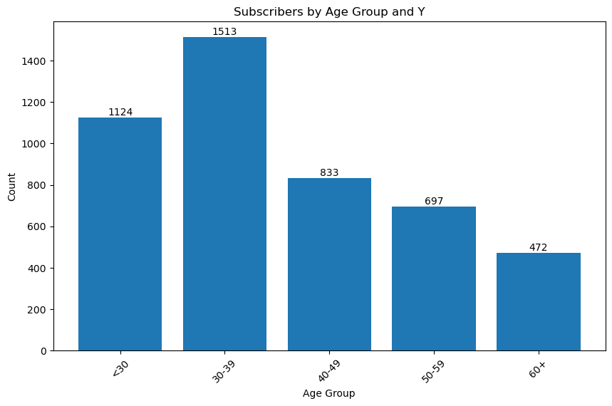

```python
# age_group_analysis
age_group_analysis = data_subscribers.groupby(['age_bin', 'y']).size()

# Convert the series to a DataFrame and reset the index
age_group_analysis = age_group_analysis.reset_index(name='count')

# Plotting
plt.figure(figsize=(10, 6))
ax = plt.bar(age_group_analysis['age_bin'], age_group_analysis['count'])

# Annotate each bar with its count value
for i, count in enumerate(age_group_analysis['count']):
    plt.text(i, count, str(count), ha='center', va='bottom')

plt.title('Subscribers by Age Group and Y')
plt.xlabel('Age Group')
plt.ylabel('Count')
plt.xticks(rotation=45)
plt.show()
```

In the above graph visualises the younger age group tends to get attracted more torward term plans, which can have variours factors like less responsibilites and more cababilty to take risk.

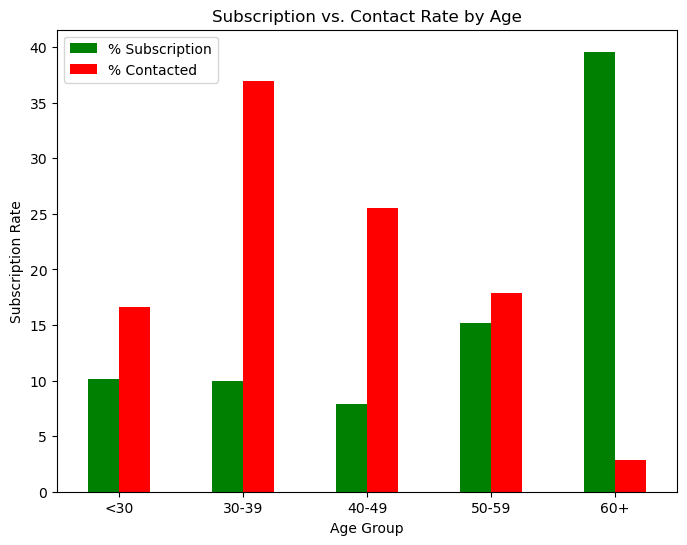

```python
count_age_response_pct = pd.crosstab(data_copy1['y'],data_copy1['age_bin']).apply(lambda x: x/x.sum() * 100)
count_age_response_pct = count_age_response_pct.transpose()

age = pd.DataFrame(data_copy1['age_bin'].value_counts())
age['% Contacted'] = age['age_bin']*100/age['age_bin'].sum()
age['% Subscription'] = count_age_response_pct['yes']
age.drop('age_bin',axis = 1,inplace = True)

age['age'] = [30,40,50,20,60]
age = age.sort_values('age',ascending = True)

plot_age = age[['% Subscription','% Contacted']].plot(kind = 'bar',
                                              figsize=(8,6), color = ('green','red'))
plt.xlabel('Age Group')
plt.ylabel('Subscription Rate')
plt.xticks(np.arange(5), ('<30', '30-39', '40-49', '50-59', '60+'),rotation = 'horizontal')
plt.title('Subscription vs. Contact Rate by Age')
plt.show()
```

However, red vertical bars show that the bank focused its marketing efforts on the middle-aged group, which returned lower subscription rates than the younger and older groups. Thus, to make the marketing campaign more effective, the bank should target younger and older clients in the future.

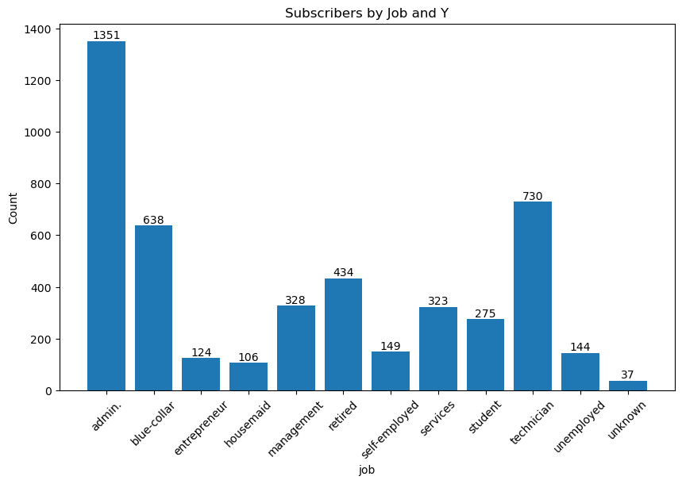

```python
job_group_analysis = data_subscribers.groupby(['job', 'y']).size()

# Convert the series to a DataFrame and reset the index
job_group_analysis = job_group_analysis.reset_index(name='count')

# Plotting
plt.figure(figsize=(10, 6))
ax = plt.bar(job_group_analysis['job'], job_group_analysis['count'])

# Annotate each bar with its count value
for i, count in enumerate(job_group_analysis['count']):
    plt.text(i, count, str(count), ha='center', va='bottom')

plt.title('Subscribers by Job and Y')
plt.xlabel('job')
plt.ylabel('Count')
plt.xticks(rotation=45)
plt.show()
```

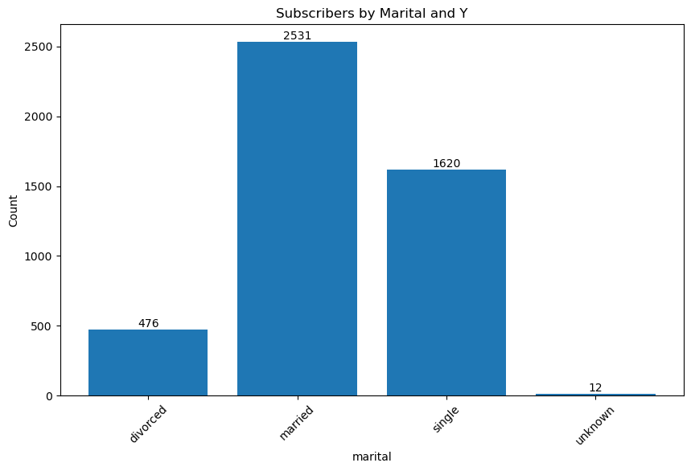

```python
marital_analysis = data_subscribers.groupby(['marital', 'y']).size()

# Convert the series to a DataFrame and reset the index
marital_analysis = marital_analysis.reset_index(name='count')

# Plotting
plt.figure(figsize=(10, 6))
ax = plt.bar(marital_analysis['marital'], marital_analysis['count'])

# Annotate each bar with its count value
for i, count in enumerate(marital_analysis['count']):
    plt.text(i, count, str(count), ha='center', va='bottom')

plt.title('Subscribers by Marital and Y')
plt.xlabel('marital')
plt.ylabel('Count')
plt.xticks(rotation=45)
plt.show()
```

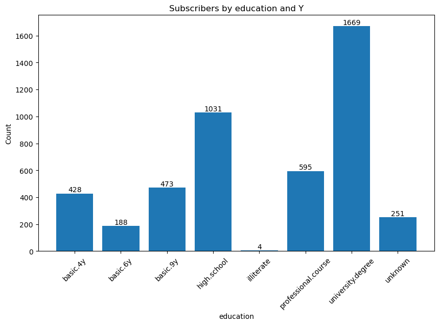

```python
education_group_analysis = data_subscribers.groupby(['education', 'y']).size()

# Convert the series to a DataFrame and reset the index
education_group_analysis = education_group_analysis.reset_index(name='count')

# Plotting
plt.figure(figsize=(10, 6))
ax = plt.bar(education_group_analysis['education'], education_group_analysis['count'])

# Annotate each bar with its count value
for i, count in enumerate(education_group_analysis['count']):
    plt.text(i, count, str(count), ha='center', va='bottom')

plt.title('Subscribers by education and Y')
plt.xlabel('education')
plt.ylabel('Count')
plt.xticks(rotation=45)
plt.show()
```

2) Customer segment risk

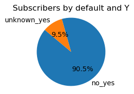

```python
# List of features to analyze
features = ['default']

# Loop through each feature
for feature in features:
    # Group by the feature and 'y', then calculate the count
    feature_group_analysis = data_subscribers.groupby([feature, 'y']).size()
    # Convert the series to a DataFrame and reset the index
    feature_group_analysis = feature_group_analysis.reset_index(name='count')

    # Prepare data for the pie chart
    labels = [f"{feature}_{y}" for feature, y in zip(feature_group_analysis[feature], feature_group_analysis['y'])]
    sizes = feature_group_analysis['count']

    # Plotting
    plt.figure(figsize=(2, 2))
    plt.pie(sizes, labels=labels, autopct='%1.1f%%', startangle=140)
    plt.title(f'Subscribers by {feature} and Y')
    plt.axis('equal')  # Equal aspect ratio ensures that pie is drawn as a circle.

    plt.show()
```

Here to satisfy the above point:cutomer hovever are not intended to get enrolled in term deposit plan, but can be also counted as risker.

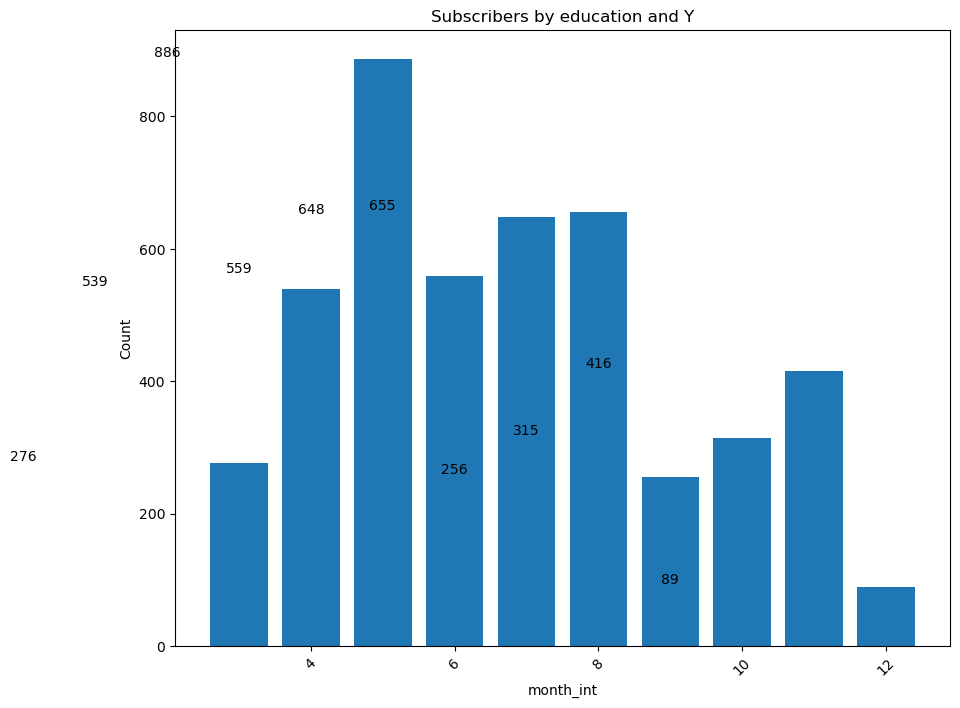

```python
month_analysis = data_subscribers.groupby(['month_int', 'y']).size()

# Convert the series to a DataFrame and reset the index
month_analysis = month_analysis.reset_index(name='count')

# Plotting
plt.figure(figsize=(10, 8))
ax = plt.bar(month_analysis['month_int'], month_analysis['count'])

# Annotate each bar with its count value
for i, count in enumerate(month_analysis['count']):
    plt.text(i, count, str(count), ha='center', va='bottom')

plt.title('Subscribers by education and Y')
plt.xlabel('month_int')
plt.ylabel('Count')
plt.xticks(rotation=45)
plt.show()
```